# Parcial 1 Probabilidad y Estadistica

Julian Velandia

Julian Albarracín

Tomas Bermudez

2025-05-14

# 1 Descripción

A continuación se presenta el desarrollo del *Parcial #1*, en el cuál se solucionan 14 puntos relacionados al análisis de estadítico de las variables de la base de datos

# 2 Desarrollo

## 2.1 Primer punto

*Enunciado:* ¿Cuál es la proporción de estudiantes por cada nivel educativo? Construya una tabla de frecuencias y un gráfico de barras.

```
##   NivelEducativo Proporcion
## 1       Primaria      0.229
## 2     Secundaria      0.288
## 3        Técnico      0.231
## 4  Universitario      0.252
```

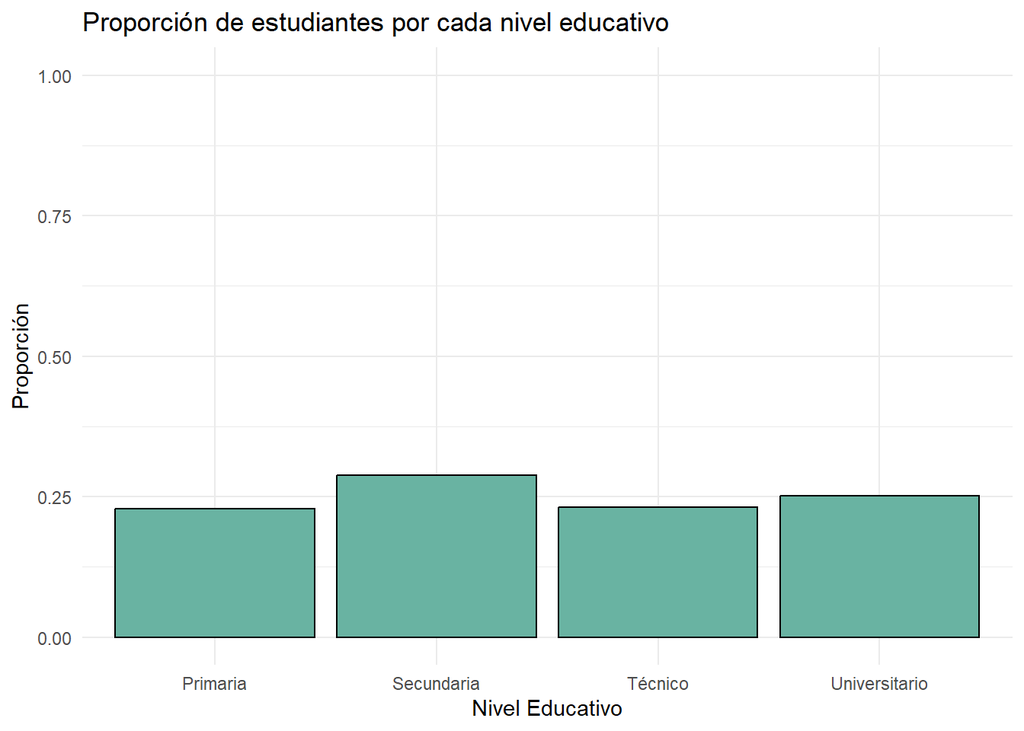

## 2.2 Segundo punto

*Enunciado:* ¿Qué porcentaje de las personas pertenece a cada género? Represente sus resultados en un gráfico de pastel.

```
##
##  Femenino Masculino      Otro
##      30.6      33.9      35.5
```

```
##
##  Femenino Masculino      Otro
##      30.6      33.9      35.5
```

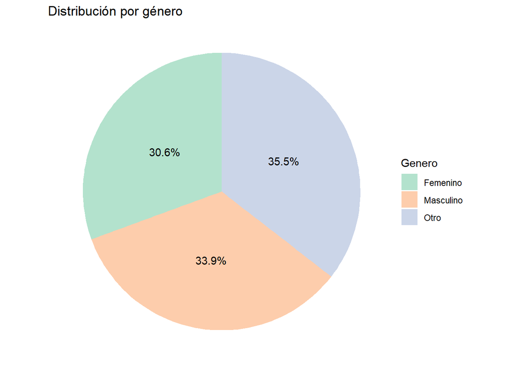

## 2.3 Tercer punto

*Enunciado:* Calcule la media, mediana y desviación estándar de la variable Edad.

```
## Media:  41.53
```

```
## Mediana:  41
```

```
## Desviación estandar:  13.72215
```

## 2.4 Cuarto punto

*Enunciado:* ¿Cuántas personas tienen más de 3 hermanos? Represente esta información en un gráfico de barras.

```
## Cantidad de personas con mas de 3 hermanos:  430
```

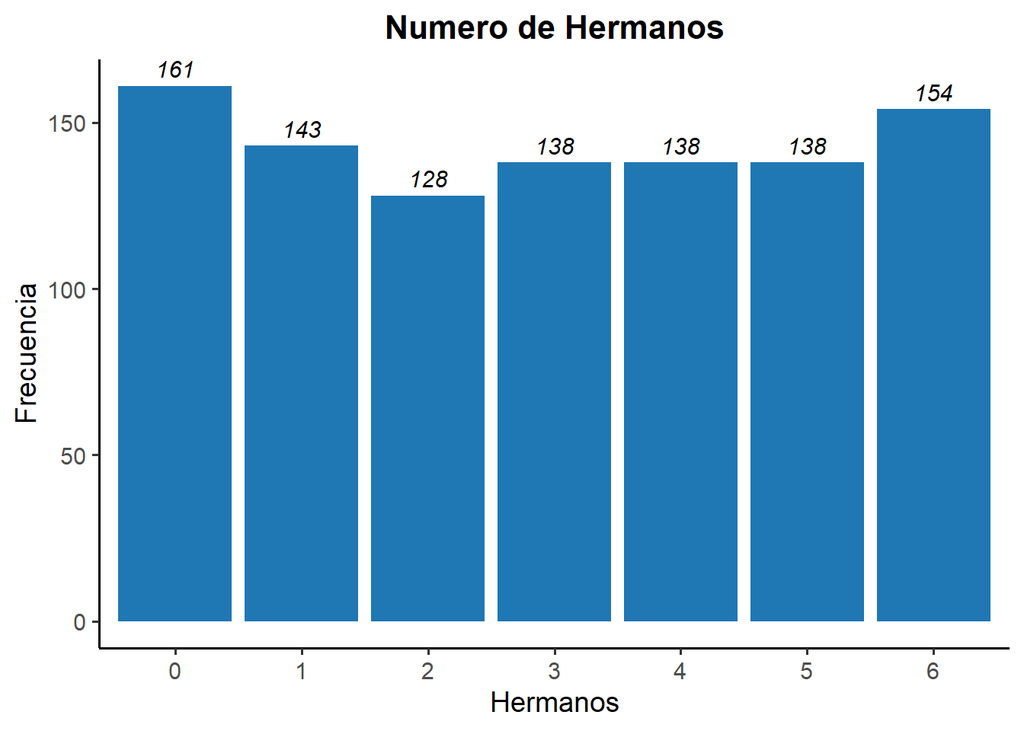

## 2.5 Quinto punto

*Enunciado:* Calcule el rango, la varianza y el coeficiente de variación de la variable IngresoMensual.

```
## Rango:  5266.7
```

```
## Varianza:  631117.3
```

```
## Coeficiente de variación:  40.22
```

## 2.6 Sexto punto

*Enunciado:* Construya un histograma de la variable Estatura. ¿Qué puede decir sobre su distribución?

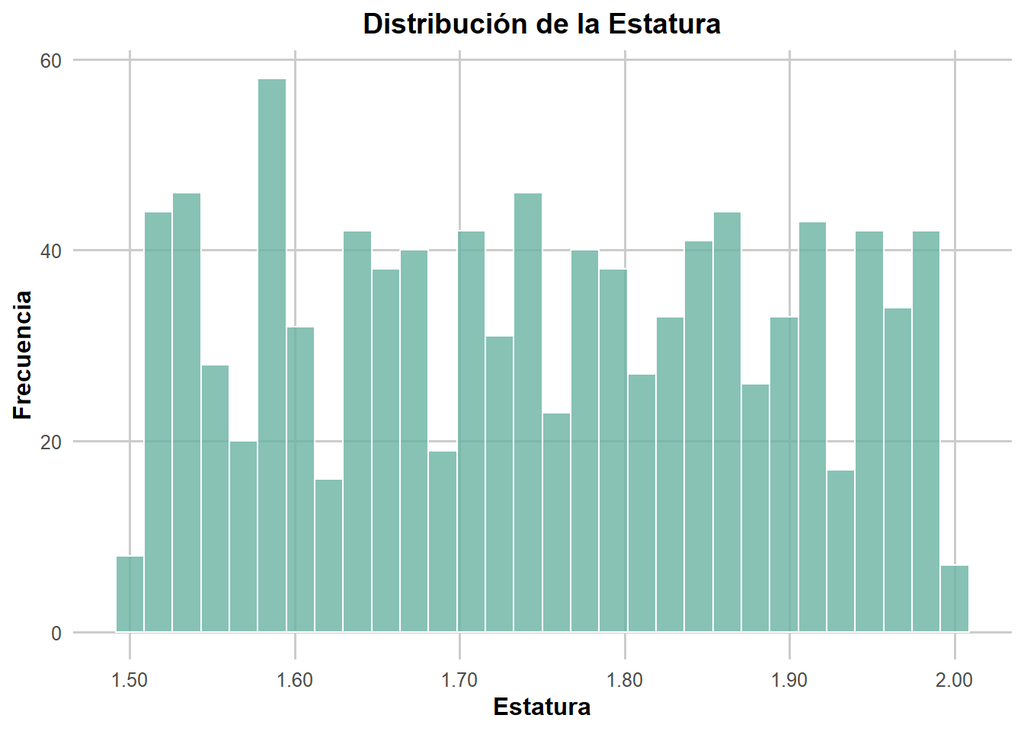

*Resultado:* La distribución de la estatura muestra una forma aproximadamente uniforme, con frecuencias similares a lo largo de todo el rango de valores, sin embargo, se observa que existe una moda que es la estatura de aproximadamente 1.58m.

## 2.7 Septimo punto

*Enunciado:* Compare las alturas promedio (Estatura) por género (Genero). ¿Cuál es la diferencia más destacada?

```
## # A tibble: 3 × 2
##   Genero    Estatura_promedio
##   <chr>                 <dbl>
## 1 Femenino               1.75
## 2 Masculino              1.74
## 3 Otro                   1.76
```

```
## Diferencia:  0.02
```

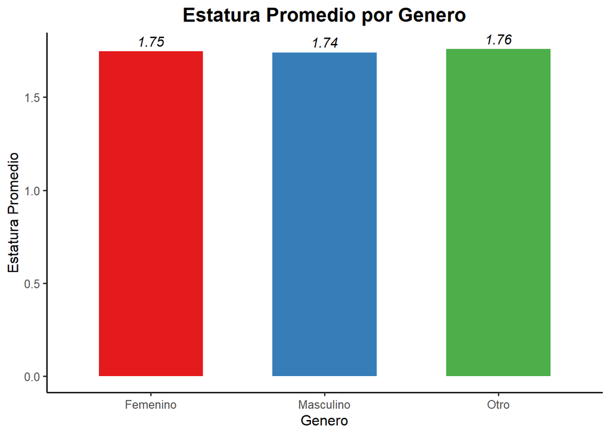

*Resultado:* La diferencia más destacada es la diferencia entre el género otro y el masculino, cuya diferencia es de 0.02m

## 2.8 Octavo punto

*Enunciado:* Analice si los ingresos promedio (IngresoMensual) varían según el nivel educativo (NivelEducativo).

```
## # A tibble: 4 × 2
##   NivelEducativo IngresoPromedio
##   <chr>                    <dbl>
## 1 Primaria                 2037.
## 2 Secundaria               2012.
## 3 Técnico                  1897.
## 4 Universitario            1948.
```

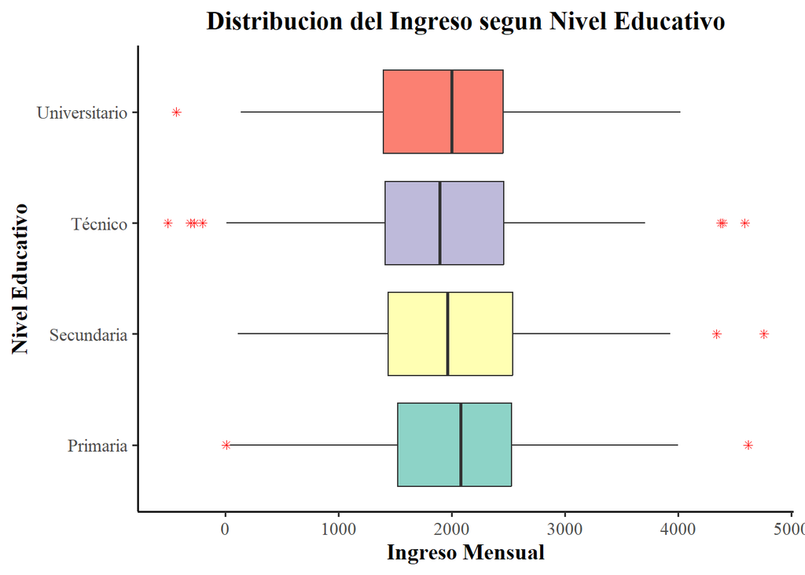

*Resultado:* A pesar de que los promedios son bastantes similares, gracias a los casos atípicos visibles en el diagrama de caja, podemos decir vagamente que las personas con menor nivel educativo tiene mayores ingresos

## 2.9 Noveno punto

*Enunciado:* Construya un diagrama de caja y bigotes para los ingresos mensuales (IngresoMensual) por nivel educativo (NivelEducativo).

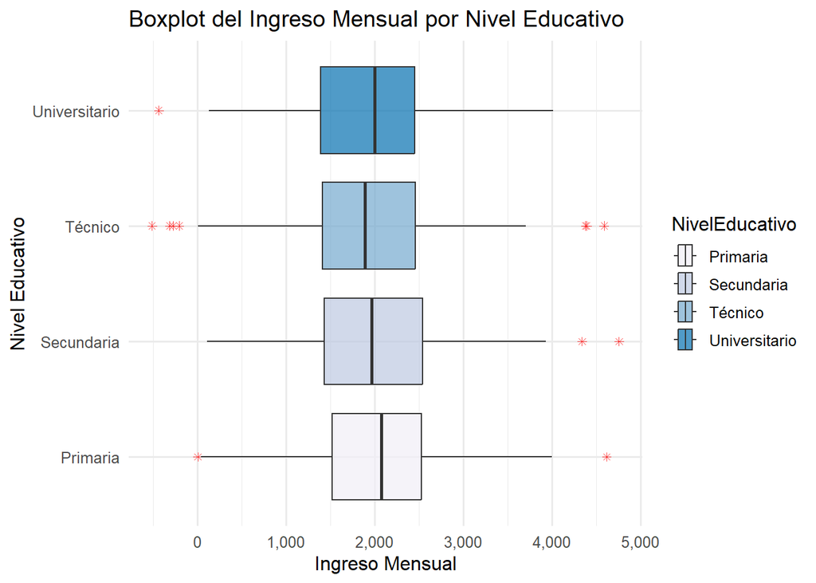

## 2.10 Decimo punto

*Enunciado:* Grafique la relación entre Edad y IngresoMensual con un gráfico de dispersión. ¿Hay alguna tendencia aparente?

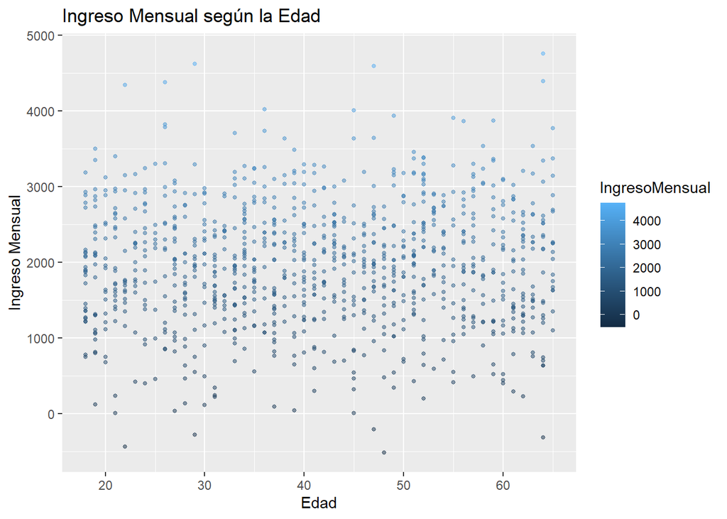

*Resultado:* No se observa alguna tendencia aparente

## 2.11 Onceavo punto

*Enunciado:* Construya una tabla de doble entrada que muestre la distribución conjunta de Genero y NivelEducativo.

```
##
##             Primaria Secundaria Técnico Universitario
##   Femenino        72         88      71            75
##   Masculino       74         93      82            90
##   Otro            83        107      78            87
```

## 2.12 Doceavo punto

*Enunciado:* Calcule la proporción de personas con más de 2 hermanos que tienen un ingreso mensual superior a $3000.

```
## Casos de condición:  53
```

```
## Casos totales:  568
```

```
## Proporción:  0.09
```

# 3 Resultados

## 3.1 Treceavo punto

*Enunciado:* A partir de los resultados obtenidos, ¿qué variables parecen tener mayor relación con el ingreso mensual? Justifique su respuesta.

*Resupuesta:* Según las graficas anterirores y un análisis de estas, podríamos decir que es muy dificil llegar las unas variables que estén relacionadas con el ingreso, sin embargo, según el diagrama de cajas del punto #9 el nivel educativo podría tener un efecto parcial pero no definitivo sobre esta variable, aparte según el punto #5 la varianza del ingreso es muy grande, lo que nos dice que los ingresos de las personas en la base de datos, son muy dispersos.

## 3.2 Catorceavo punto

*Enunciado:* Si quisiera predecir la estatura de una persona basándote en otras variables, ¿qué variable(s) elegiría y por qué?

*Resupuesta:* según los puntos anteriores, la estatura no se ve muy definida por alguna otra variable, sin embargo, según la gráfica del punto #7 podríamos decir que influye, aunque las diferencias no sean muy significativas